# STA 141C Final Project

Yaosong Zhan

2020/3/19

Import library

```r
library(ggplot2)
library(tidyverse)
library(readr)
```

Import data

```r
url1 <- "https://archive.ics.uci.edu/ml/machine-learning-databases/adult/adult.data"
data1 <- read.csv(url1, header = FALSE)

colnames(data1) <- c("age",
                     "workclass",
                     "fnlwgt",
                     "education",
                     "education_num",
                     "marital_status",
                     "occupation",
                     "relationship",
                     "race",
                     "sex",
                     "capital_gain",
                     "capital_loss",
                     "hours_per_week",
                     "native-country",
                     "income")
attach(data1)
```

Plot the figure of relationship between sex and income

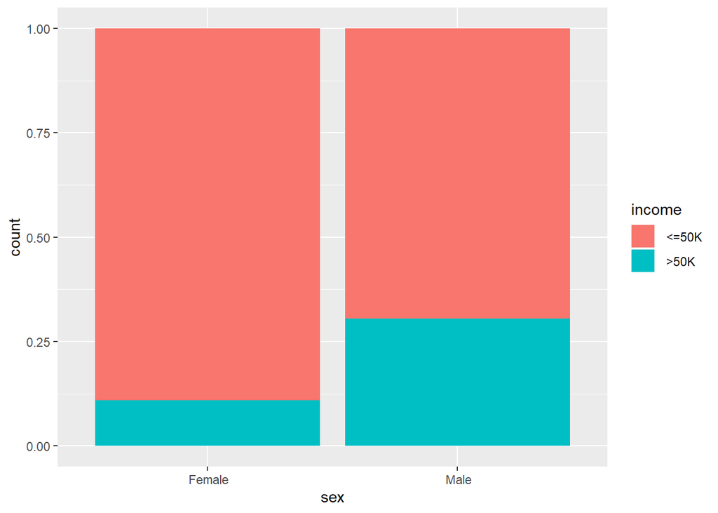

```r
fig = ggplot(data = data1, mapping = aes(x = sex, fill = income))
fig + geom_bar(position = "fill")
```

The percentage of income > 50K in the male group is higher than that in the female group

Plot the number of income > 50K and income <=50K grouped by sex and education_num

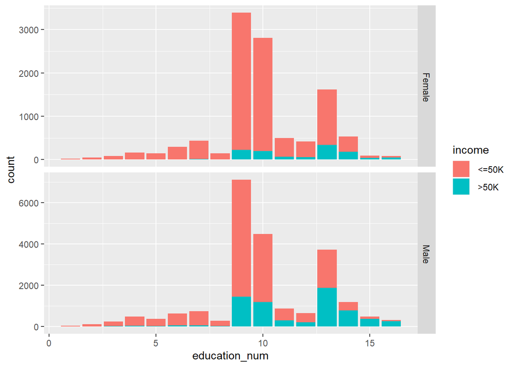

```r
fig = ggplot(data = data1, mapping = aes(x = education_num, fill = income))
fig + geom_bar() + facet_grid(sex, scales = "free_y")
```

Plot the number of income > 50K and income <=50K grouped by race and education

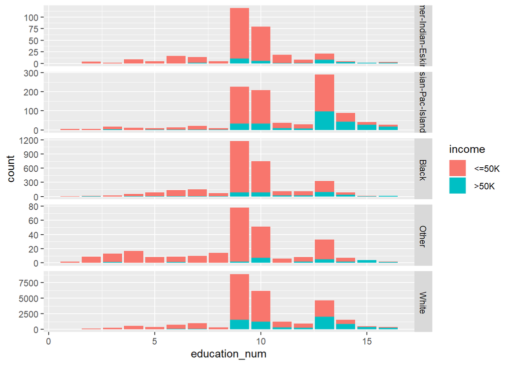

```r
fig = ggplot(data = data1, mapping = aes(x = education_num, fill = income))
fig + geom_bar() + facet_grid(race, scales = "free_y")
```

Plot the distribution of age groupped by income

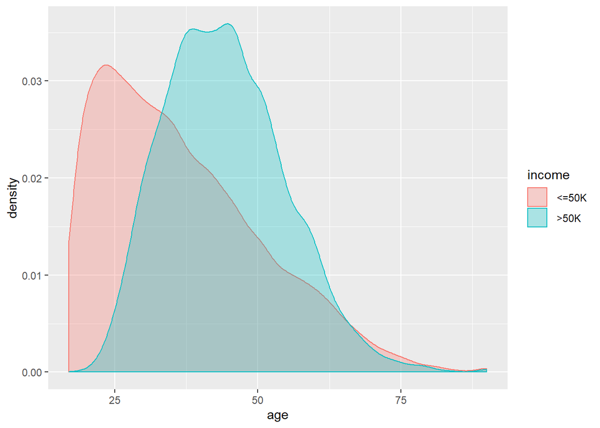

```r
fig = ggplot(data = data1, mapping = aes(x = age, fill = income, color = income))
fig + geom_density(alpha = 0.3)
```

We find that the distribution of age in income < 50K group and income > 50K group are different. In the income < 50K group, the peak of age distribution is below 25, while in the income > 50K, the maximum of the distribution is around 40.

Plot the percentage of income >= 50K in each hours_per_week group

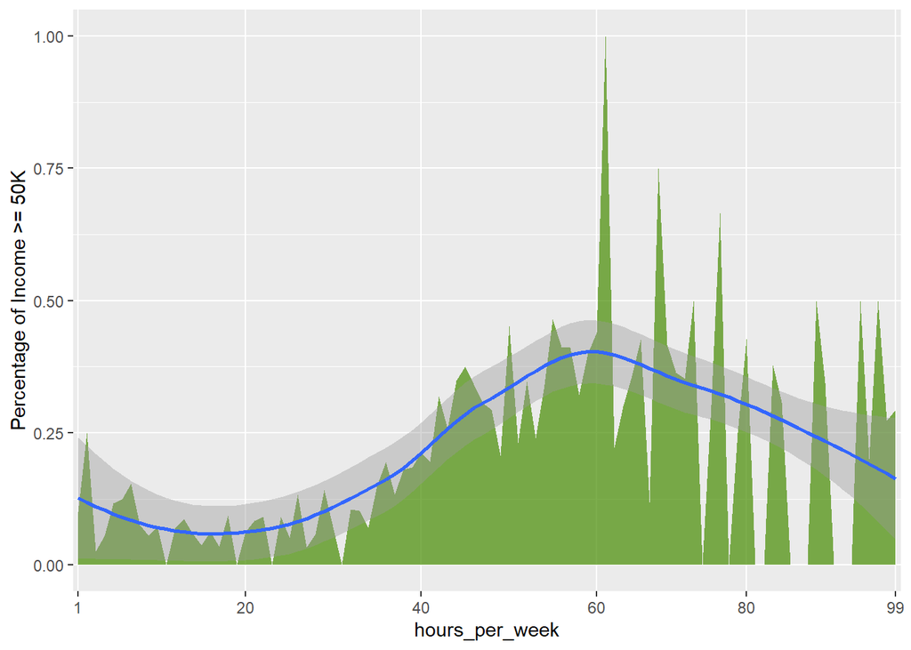

```r
hours_income = table(data1[,c('hours_per_week','income')])
hours_income <- as.data.frame(prop.table(hours_income, 1))
hours_income_over50 = hours_income[(nrow(hours_income)/2+1):nrow(hours_income),]
fig = ggplot(data = hours_income_over50,
             mapping = aes(
             x = hours_per_week,
             y = Freq,
             group = income))
fig + geom_area(fill = "chartreuse4",alpha = 0.7) + geom_smooth()+
  scale_x_discrete(
    breaks = c(1, 20, 40, 60, 80, 99)
  )+
  labs(
    y = "Percentage of Income >= 50K"
  )
```

Plot the distribution of captial_gain and capital_loss

```r
data1 = data1 %>% mutate(
  capital_gain_over0 = if_else(capital_gain > 0,"Capital Gain > 0","Capital Gain = 0"),
  capital_loss_over0 = if_else(capital_loss > 0,"Capital loss > 0","Capital loss = 0"))
```

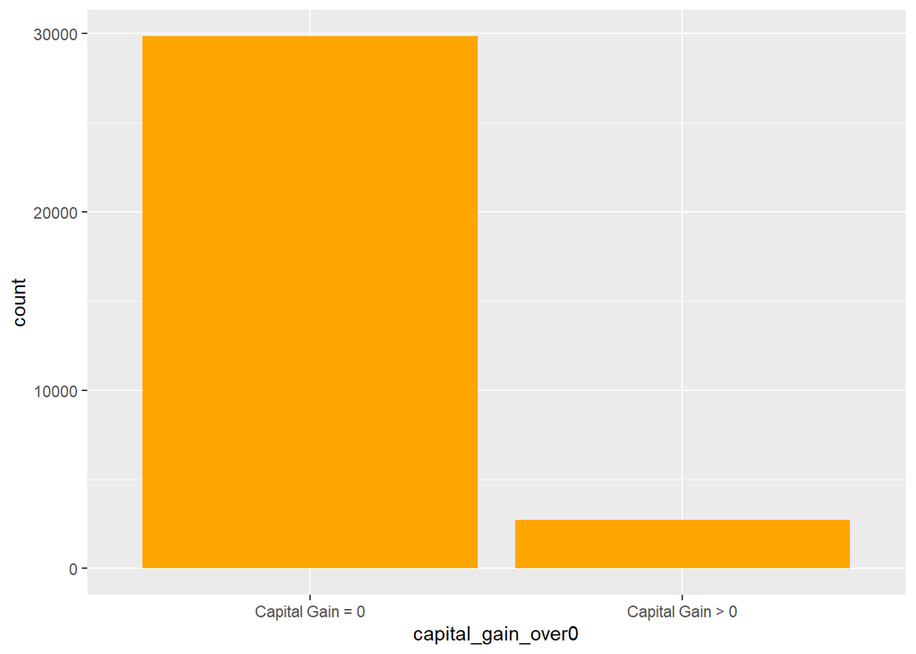

```r
fig = ggplot(data = data1, mapping = aes(x = capital_gain_over0))
fig + geom_bar(fill = 'orange')
```

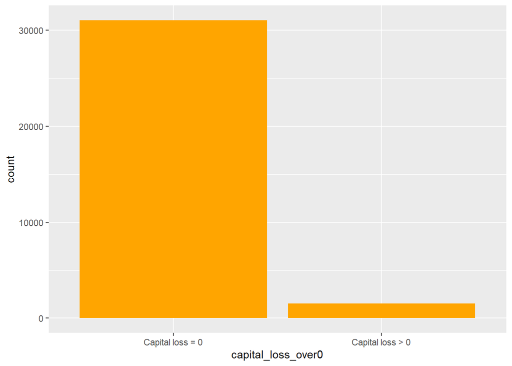

```r
fig = ggplot(data = data1, mapping = aes(x = capital_loss_over0))
fig + geom_bar(fill = 'orange')
```